# Applied Data Science Capstone Porject: Battles of Neighborhoods

[figure not shown]

For this capstone project, imagine that you live in the west side of the city of Toronto of Canada. You receive a job offer on the other side of the city with great career prospects. However, given the long distance from your current place, you must relocate if you accept the job offer. You would like to relocate to a neighborhood that is exactly the same as your current one, if not, at least to neighborhoods that are closer to your new job.

If this capstone project, you can compare different neighborhoods in terms of service, search for potential explanation of why a particular neighborhood is popular, or complaints in other neighborhood. Hence the name of the project will be Battles of Neighborhoods.

You will segment the city of Toronto into different neighborhoods, using the geographical coordinates of the center of each neighborhood, then using a combination of location data and machine learning, you will group the neighborhoods into clusters like the following:

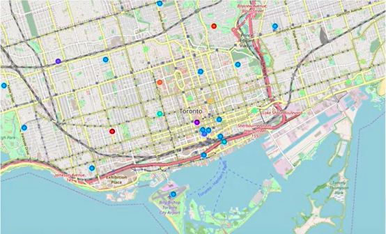

There are many location data providers. As far as this capstone project is concerned, we will be usig the Foursquare location data set.

Example of location data:

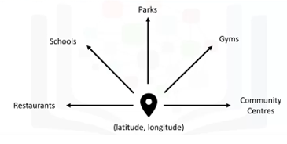

Let's get started!

```python
import pandas as pd
import numpy as np
```

```python
print("Hello, capstone project course!")
```

```
Hello, capstone project course!
```